# Exam 1

## Exam 1

#### Metainformation

1. | Tag | Value |
   | --- | --- |
   | `file` | Inferential_Statistics_vufsw-ancova-2074-nl_vufsw-ancova-2074-nl |
   | `name` | vufsw-ancova-2074-nl |
   | `section` | inferential statistics/parametric techniques/anova/ancova |
   | `type` | schoice |
   | `solution` | TRUE, FALSE, FALSE, FALSE |
   | `ID` | 8f1dc |
   | `Type` | interpreting output |
   | `Program` | NA |
   | `Language` | Dutch |
   | `Level` | statistical reasoning |

#### Question

   In een experiment werden deelnemers random verdeeld over twee groepen (groepsvariabele: ERROR_APPROACH) die een taak moesten uitvoeren. De beide groepen werden vooraf verschillend geïnstrueerd: error prevention (“ je mag geen fouten maken” ) en error management (“ je mag fouten maken, je leert ervan”). Hieronder staat een serie AN(C)OVA analyses waarin onderzocht is of de ‘error-approach’ van invloed is op hoe goed de taak is uitgevoerd (PERFORMANCE). SELFCONTROL (mate van zelfdiscipline, gemeten voorafgaand aan het experiment) is in deze analyses een covariaat.

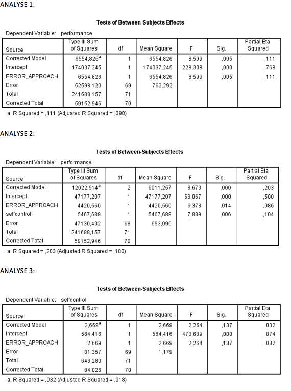

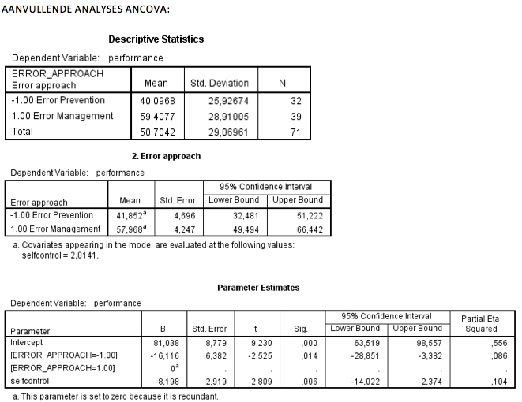

   Hoe toets je of voldaan is aan de assumptie van de ‘homogeneity of regression slopes’ van ANCOVA voldaan?
   1. **TRUE:** Door aan analyse 2 de interactie tussen selfcontrol en error-approach toe te voegen; de *F*-waarde van het interactie-effect tussen beide toetst de assumptie
   2. **FALSE:** Door aan analyse 2 de interactie tussen selfcontrol en error-approach toe te voegen; de *F*-waarde van het ‘corrected model’ toetst deze assumptie
   3. **FALSE:** Door selfcontrol als afhankelijke variabele te nemen en error-approach als onafhankelijke; de *F*-waarde van het ‘corrected model’ toetst deze assumptie
   4. **FALSE:** Door selfcontrol als afhankelijke variabele te nemen en error-approach als onafhankelijke; de *F*-waarde van het interactie-effect tussen beide toetst de assumptie
   1. True
   2. False
   3. False
   4. False